# Time Series Analysis

##### 8.Loosely interpret the coefficient estimates of the model you selected in part 7.

```r
fit200$coef
```

```
##         ar1         ar2   intercept
## -0.27826475 -0.22471427  0.01998718
```

The intercept is .02, this means that the data averages around .02 when x is 0. The ar1 coefficient of -.28 means that the t-1 value impacts the current value by -.28x, and the t-2 value impacts the current value by -.22.

##### 9. Perform diagnostic tests for the best model by assessing:

###### a. The constant variance assumption (graphically).

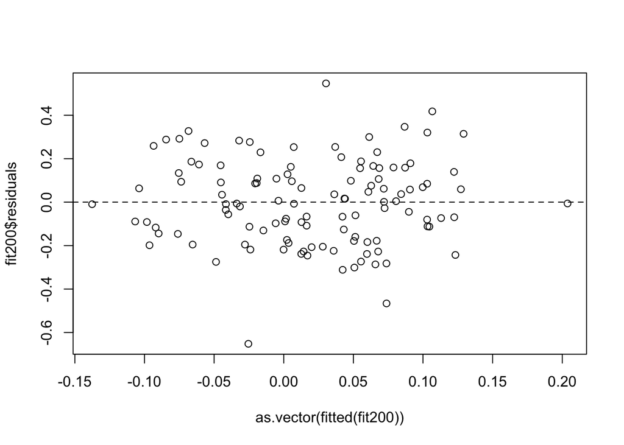

```r
plot(as.vector(fitted(fit200)), fit200$residuals)
abline(h = 0, lty = 2)
```

Maybe a violation of constant variance, not clear.

###### b. The normality assumption (graphically).

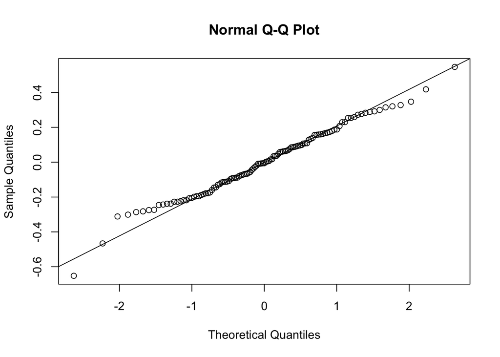

```r
qqnorm(fit200$residuals)
qqline(fit200$residuals)
```

Might be an issue as well.